# Self-Driving Car Engineer Nanodegree

## Project: Build a Traffic Sign Recognition Classifier

In this notebook, a template is provided for you to implement your functionality in stages, which is required to successfully complete this project. If additional code is required that cannot be included in the notebook, be sure that the Python code is successfully imported and included in your submission if necessary.

In addition to implementing code, there is a writeup to complete. The writeup should be completed in a separate file, which can be either a markdown file or a pdf document. There is a [write up template](https://github.com/udacity/CarND-Traffic-Sign-Classifier-Project/blob/master/writeup_template.md) that can be used to guide the writing process. Completing the code template and writeup template will cover all of the [rubric points](https://review.udacity.com/#!/rubrics/481/view) for this project.

The [rubric](https://review.udacity.com/#!/rubrics/481/view) contains "Stand Out Suggestions" for enhancing the project beyond the minimum requirements. The stand out suggestions are optional. If you decide to pursue the "stand out suggestions", you can include the code in this Ipython notebook and also discuss the results in the writeup file.

> **Note:** Code and Markdown cells can be executed using the **Shift + Enter** keyboard shortcut. In addition, Markdown cells can be edited by typically double-clicking the cell to enter edit mode.

## Step 0: Load The Data

```python
# Load pickled data
import pickle

# TODO: Fill this in based on where you saved the training and testing data

training_file = "../data/train.p"
validation_file= "../data/valid.p"
testing_file = "../data/test.p"

with open(training_file, mode='rb') as f:
    train = pickle.load(f)
with open(validation_file, mode='rb') as f:
    valid = pickle.load(f)
with open(testing_file, mode='rb') as f:
    test = pickle.load(f)

X_train, y_train = train['features'], train['labels']
X_valid, y_valid = valid['features'], valid['labels']
X_test, y_test = test['features'], test['labels']
```

## Step 1: Dataset Summary & Exploration

The pickled data is a dictionary with 4 key/value pairs:

- `'features'` is a 4D array containing raw pixel data of the traffic sign images, (num examples, width, height, channels).
- `'labels'` is a 1D array containing the label/class id of the traffic sign. The file `signnames.csv` contains id -> name mappings for each id.
- `'sizes'` is a list containing tuples, (width, height) representing the original width and height the image.
- `'coords'` is a list containing tuples, (x1, y1, x2, y2) representing coordinates of a bounding box around the sign in the image. **THESE COORDINATES ASSUME THE ORIGINAL IMAGE. THE PICKLED DATA CONTAINS RESIZED VERSIONS (32 by 32) OF THESE IMAGES**

Complete the basic data summary below. Use python, numpy and/or pandas methods to calculate the data summary rather than hard coding the results. For example, the [pandas shape method](http://pandas.pydata.org/pandas-docs/stable/generated/pandas.DataFrame.shape.html) might be useful for calculating some of the summary results.

### Provide a Basic Summary of the Data Set Using Python, Numpy and/or Pandas

```python
### Replace each question mark with the appropriate value.
### Use python, pandas or numpy methods rather than hard coding the results

# TODO: Number of training examples
n_train = len(X_train)

# TODO: Number of validation examples
n_validation = len(X_valid)

# TODO: Number of testing examples.
n_test = len(X_test)

# TODO: What's the shape of an traffic sign image?
image_shape = X_train[0].shape

# TODO: How many unique classes/labels there are in the dataset.
# n_classes = len(set(y_train))
# n_classes = len(set(y_valid))
n_classes = len(set(y_test))

print("Number of training examples =", n_train)
print("Number of testing examples =", n_test)
print("Number of validating examples =", n_test)
print("Image data shape =", image_shape)
print("Number of classes =", n_classes)
```

[output not shown]

### Include an exploratory visualization of the dataset

Visualize the German Traffic Signs Dataset using the pickled file(s). This is open ended, suggestions include: plotting traffic sign images, plotting the count of each sign, etc.

The [Matplotlib](http://matplotlib.org/) [examples](http://matplotlib.org/examples/index.html) and [gallery](http://matplotlib.org/gallery.html) pages are a great resource for doing visualizations in Python.

**NOTE:** It's recommended you start with something simple first. If you wish to do more, come back to it after you've completed the rest of the sections. It can be interesting to look at the distribution of classes in the training, validation and test set. Is the distribution the same? Are there more examples of some classes than others?

```python
### Data exploration visualization code goes here.
### Feel free to use as many code cells as needed.
import matplotlib.pyplot as plt
import random
import numpy as np
# Visualizations will be shown in the notebook.
%matplotlib inline
# index  = random.randint(0,len(X_train))
# img = X_train[index].squeeze()
# plt.figure(figsize=(2,2))
# plt.imshow(img,cmap='gray')
# print(y_train[index])
```

```python
import matplotlib.pyplot as plt
import random
import numpy as np
import pandas as pd
%matplotlib inline

lable_names = pd.read_csv("signnames.csv")
```

#### Training Set Image Visualization

```python
def df_labels(lable_ids,lable_names):
    map_list = []
    for i in range(len(lable_ids)):
        label_id = lable_ids[i]
        label_name = lable_names[lable_names["ClassId"] == label_id]["SignName"].values[0]
        map_list.append({"image_id":i,"label_id":label_id,"label_name":label_name})
    return pd.DataFrame(map_list)
```

```python
df1 = df_labels(y_train,lable_names)
```

```python
df1.head(n=5)
```

|  | image_id | label_id | label_name |
| --- | --- | --- | --- |
| 0 | 0 | 41 | End of no passing |
| 1 | 1 | 41 | End of no passing |
| 2 | 2 | 41 | End of no passing |
| 3 | 3 | 41 | End of no passing |
| 4 | 4 | 41 | End of no passing |

```python
df2 = pd.pivot_table(df1,index=["label_id","label_name"],values="image_id",aggfunc="count")
```

```python
df2.head(n=5)
```

| label_id | label_name | image_id |
| --- | --- | --- |
| 0 | Speed limit (20kph) | 180 |
| 1 | Speed limit (30kph) | 1980 |
| 2 | Speed limit (50kph) | 2010 |
| 3 | Speed limit (60kph) | 1260 |
| 4 | Speed limit (70kph) | 1770 |

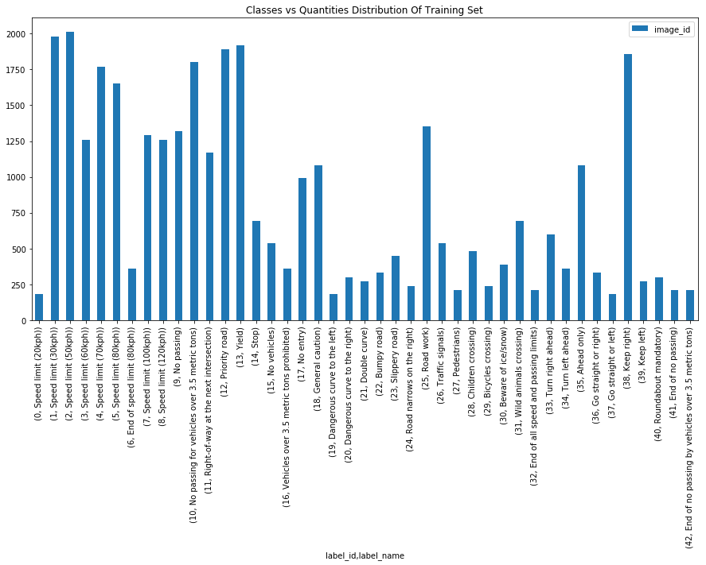

```python
# http://pandas.pydata.org/pandas-docs/stable/generated/pandas.DataFrame.plot.html#pandas.DataFrame.plot
df2.plot(kind='bar',figsize=(15,7),title="Classes vs Quantities Distribution Of Training Set")
```

```python
def show_images(images, labels, title, cols=2, fig_size=(15, 15), show_ticks=True):
    img_cnt = len(images)
    if (img_cnt % cols) == 0:
        rows = int(img_cnt/cols)
    else:
        rows = int(img_cnt/cols) + 1
    cmap = None
#     print("(",rows,",",cols,")")
    fig,ax = plt.subplots(rows,cols,figsize=fig_size)
    if rows > 1:
        for i in range(rows):
            for j in range(cols):
                k = i*cols + j
                if k < img_cnt:
                    img_title = labels[k]
                    img = images[k]

                    if len(img.shape)<3 or img.shape[-1]<3:
                        #grayscale image
                        cmap = "gray"
                        img = np.reshape(img, (img.shape[0], img.shape[1]))

                    ax[i][j].set_title(img_title)
                    ax[i][j].imshow(img,cmap=cmap)

                if not show_ticks:
                    ax[i][j].axis("off")
    else:
        for k in range(cols):
            if k < img_cnt:
                img_title = labels[k]
                img = images[k]

                if len(img.shape)<3 or img.shape[-1]<3:
                    #grayscale image
                    cmap = "gray"
                    img = np.reshape(img, (img.shape[0], img.shape[1]))

                ax[k].set_title(img_title)
                ax[k].imshow(img,cmap=cmap)

            if not show_ticks:
                ax[k].axis("off")

    fig.suptitle(title, fontsize=12, fontweight='bold', y = 0.6)
    fig.tight_layout()
    plt.show()

def ramdon_show_images(images,lable_ids,lable_names,fsize,show_num=5):
    label_groups = df_labels(lable_ids,lable_names).groupby(["label_id","label_name"])
    for (lbl_id,lbl_name),group in label_groups:
        index  = np.random.randint(0,high=group['image_id'].size,size=show_num,dtype='int')
        rows = group.iloc[index]
        imgs = list(map(lambda img_id:images[img_id],rows['image_id']))
        lbls = list(map(lambda label_id:label_id,rows['label_id']))
        show_images(imgs, lbls, "{0}:{1}".format(lbl_id,lbl_name), cols=show_num, fig_size=fsize, show_ticks=False)
```

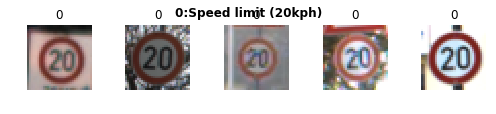

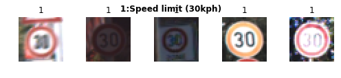

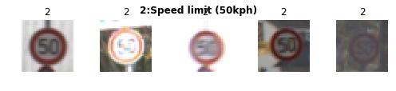

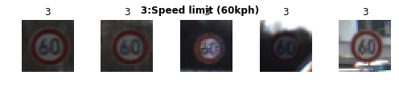

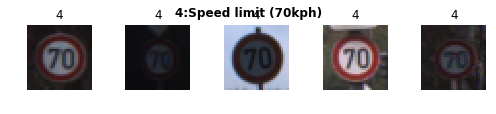

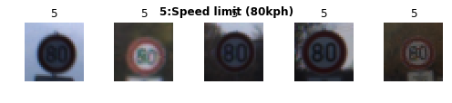

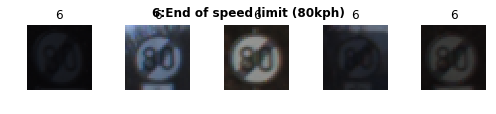

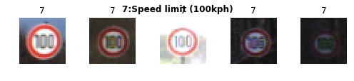

[figure not shown]

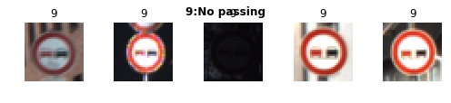

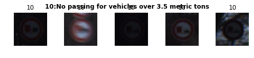

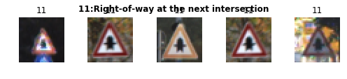

[31 more figures not shown]

```python
ramdon_show_images(X_train,y_train,lable_names,(7,7))
```

#### Validating Set Image Visualization

```python
def visualization(lable_ids,lable_names,fsize,title):
    map_list = []
    for i in range(len(lable_ids)):
        label_id = lable_ids[i]
        label_name = lable_names[lable_names["ClassId"] == label_id]["SignName"].values[0]
        map_list.append({"image_id":i,"label_id":label_id,"label_name":label_name})
    df1 = pd.DataFrame(map_list)
    df2 = pd.pivot_table(df1,index=['label_id','label_name'],values='image_id',aggfunc='count')
    df2.plot(kind='bar',figsize=fsize,title=title)
```

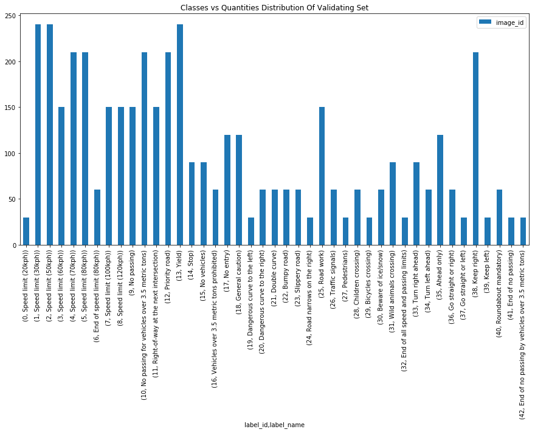

```python
visualization(y_valid,lable_names,(15,7),title="Classes vs Quantities Distribution Of Validating Set")
```

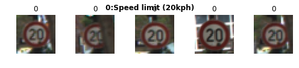

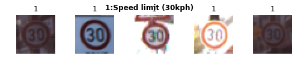

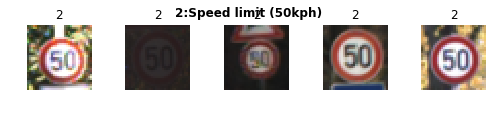

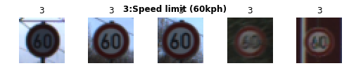

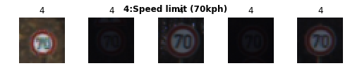

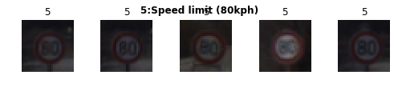

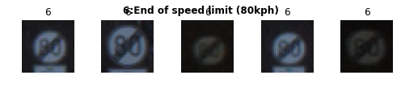

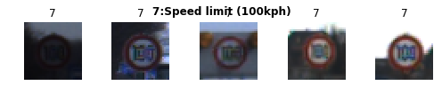

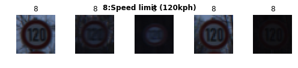

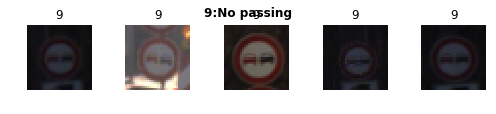

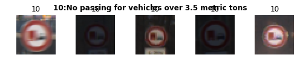

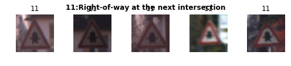

[31 more figures not shown]

```python
ramdon_show_images(X_valid,y_valid,lable_names,(7,7))
```

```python
# visualization(y_test,lable_names,(15,7))
```

## Step 2: Design and Test a Model Architecture

Design and implement a deep learning model that learns to recognize traffic signs. Train and test your model on the [German Traffic Sign Dataset](http://benchmark.ini.rub.de/?section=gtsrb&subsection=dataset).

The LeNet-5 implementation shown in the classroom at the end of the CNN lesson is a solid starting point. You'll have to change the number of classes and possibly the preprocessing, but aside from that it's plug and play!

With the LeNet-5 solution from the lecture, you should expect a validation set accuracy of about 0.89. To meet specifications, the validation set accuracy will need to be at least 0.93. It is possible to get an even higher accuracy, but 0.93 is the minimum for a successful project submission.

There are various aspects to consider when thinking about this problem:

- Neural network architecture (is the network over or underfitting?)
- Play around preprocessing techniques (normalization, rgb to grayscale, etc)
- Number of examples per label (some have more than others).
- Generate fake data.

Here is an example of a [published baseline model on this problem](http://yann.lecun.com/exdb/publis/pdf/sermanet-ijcnn-11.pdf). It's not required to be familiar with the approach used in the paper but, it's good practice to try to read papers like these.

### Pre-process the Data Set (normalization, grayscale, etc.)

Minimally, the image data should be normalized so that the data has mean zero and equal variance. For image data, `(pixel - 128)/ 128` is a quick way to approximately normalize the data and can be used in this project.

Other pre-processing steps are optional. You can try different techniques to see if it improves performance.

Use the code cell (or multiple code cells, if necessary) to implement the first step of your project.

```python
### Preprocess the data here. It is required to normalize the data. Other preprocessing steps could include
### converting to grayscale, etc.
### Feel free to use as many code cells as needed.
import numpy as np

## method1
# def normalization(img_data):
#     return (img_data - 128)/128

## method2
def normalization(img_data):
    return (img_data - np.mean(img_data))/np.std(img_data)
# X_train_norm = normalization(X_train)
# INPUT_DEPTH = 3

## method3
import cv2
def grayscale(img_data):
    return cv2.cvtColor(img_data, cv2.COLOR_RGB2GRAY)
# plt.imshow(grayscale(img),cmap='gray')
```

```python
a = np.array([1,100,33,77])
normalization(a)
```

```
array([-1.34874172,  1.23145983, -0.51473718,  0.63201907])
```

```python
print(a)
mean = np.mean(a)
std = np.std(a)
b = (a - mean)/std
b
```

```
[  1 100  33  77]
```

```
array([-1.34874172,  1.23145983, -0.51473718,  0.63201907])
```

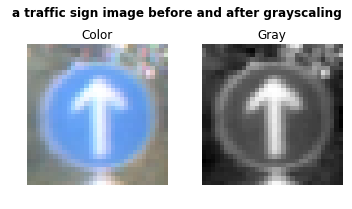

```
35
```

```python
import matplotlib.pyplot as plt
import random
import numpy as np
# Visualizations will be shown in the notebook.
%matplotlib inline
index  = random.randint(0,len(X_train))
img = X_train[index].squeeze()
fig,ax = plt.subplots(1,2,figsize=(5,5))
ax[0].set_title("Color")
ax[0].imshow(img)
ax[0].axis("off")
ax[1].set_title("Gray")
ax[1].imshow(grayscale(img),cmap='gray')
ax[1].axis("off")
fig.suptitle("a traffic sign image before and after grayscaling", fontsize=12, fontweight='bold', y = 0.8)
fig.tight_layout()
plt.show()
print(y_train[index])
```

```python
# INPUT_DEPTH = 1
X_train_gray = np.asarray(list(map(lambda img: grayscale(img), X_train)))
X_train_gray = np.reshape(X_train_gray,(X_train.shape[0],32,32,1))
X_train = normalization(X_train_gray)

X_valid_gray = np.asarray(list(map(lambda img: grayscale(img), X_valid)))
X_valid_gray = np.reshape(X_valid_gray,(X_valid.shape[0],32,32,1))
X_valid = normalization(X_valid_gray)
```

### Model Architecture

```python
import tensorflow as tf
### Shuffle the training data.
from sklearn.utils import shuffle

# The EPOCH and BATCH_SIZE values affect the training speed and model accuracy.
EPOCHS = 100
BATCH_SIZE = 512

INPUT_DEPTH = 1
n_classes = 43
```

```python
### Define your architecture here.
### Feel free to use as many code cells as needed.
from tensorflow.contrib.layers import flatten

def LeNet(x):
    mu = 0
    sigma = 0.1

## Layer 1: Convolutional. Input = 32x32x1. Output = 28x28x32.

# 6.3.3. CONSTANT OP
# tf.truncated_normal(
#     shape,
#     mean=0.0,
#     stddev=1.0,
#     dtype=tf.float32,
#     seed=None,
#     name=None
# )
# Args:
# shape: A 1-D integer Tensor or Python array. The shape of the output tensor.
# mean: A 0-D Tensor or Python value of type dtype. The mean of the truncated normal distribution.
# stddev: A 0-D Tensor or Python value of type dtype. The standard deviation of the normal distribution, before truncation.
# dtype: The type of the output.
# seed: A Python integer. Used to create a random seed for the distribution. See tf.set_random_seed for behavior.
# name: A name for the operation (optional).
    conv1_W = tf.Variable(tf.truncated_normal(shape=(5,5,INPUT_DEPTH,32), mean = mu,stddev = sigma))
    conv1_b = tf.Variable(tf.zeros(32))

# Module: tf.nn
# Defined in tensorflow/nn/__init__.py.
# Wrappers for primitive Neural Net (NN) Operations.
# https://www.tensorflow.org/api_docs/python/tf/nn/conv2d
# tf.nn.conv2d(
#     input,
#     filter,
#     strides,
#     padding,
#     use_cudnn_on_gpu=True,
#     data_format='NHWC',
#     dilations=[1, 1, 1, 1],
#     name=None
# )

# Computes a 2-D convolution given 4-D input and filter tensors.
# Given an input tensor of shape [batch, in_height, in_width, in_channels] and a filter / kernel tensor of shape [filter_height, filter_width, in_channels, out_channels], this op performs the following:
# Flattens the filter to a 2-D matrix with shape [filter_height * filter_width * in_channels, output_channels].
# Extracts image patches from the input tensor to form a virtual tensor of shape [batch, out_height, out_width, filter_height * filter_width * in_channels].
# For each patch, right-multiplies the filter matrix and the image patch vector.
# In detail, with the default NHWC format,
# output[b, i, j, k] =
#     sum_{di, dj, q} input[b, strides[1] * i + di, strides[2] * j + dj, q] *
#                     filter[di, dj, q, k]
# Must have strides[0] = strides[3] = 1. For the most common case of the same horizontal and vertices strides, strides = [1, stride, stride, 1].

# Args:
# input: A Tensor. Must be one of the following types: half, bfloat16, float32, float64. A 4-D tensor. The dimension order is interpreted according to the value of data_format, see below for details.
# filter: A Tensor. Must have the same type as input. A 4-D tensor of shape [filter_height, filter_width, in_channels, out_channels]
# strides: A list of ints. 1-D tensor of length 4. The stride of the sliding window for each dimension of input. The dimension order is determined by the value of data_format, see below for details.
# padding: A string from: "SAME", "VALID". The type of padding algorithm to use.
# use_cudnn_on_gpu: An optional bool. Defaults to True.
# data_format: An optional string from: "NHWC", "NCHW". Defaults to "NHWC". Specify the data format of the input and output data. With the default format "NHWC", the data is stored in the order of: [batch, height, width, channels]. Alternatively, the format could be "NCHW", the data storage order of: [batch, channels, height, width].
# dilations: An optional list of ints. Defaults to [1, 1, 1, 1]. 1-D tensor of length 4. The dilation factor for each dimension of input. If set to k > 1, there will be k-1 skipped cells between each filter element on that dimension. The dimension order is determined by the value of data_format, see above for details. Dilations in the batch and depth dimensions must be 1.
# name: A name for the operation (optional).
    conv1 = tf.nn.conv2d(x,conv1_W,strides=[1,1,1,1],padding='VALID') + conv1_b

# Activation. Your choice of activation function.
    conv1 = tf.nn.relu(conv1)

# Pooling. Input = 28x28x32. Output = 14x14x32.
# tf.nn.max_pool(
#     value,
#     ksize,
#     strides,
#     padding,
#     data_format='NHWC',
#     name=None
# )
    conv1 = tf.nn.max_pool(conv1,ksize=[1,2,2,1],strides=[1,2,2,1],padding='VALID')
# Apply dropout - even at the conv level
    conv1 = tf.nn.dropout(conv1,0.75)

## Layer 2: Convolutional. The input shape is 14x14x32,The output shape should be 10x10x64.
    conv2_W = tf.Variable(tf.truncated_normal(shape=[5,5,32,64], mean = mu, stddev = sigma))
    conv2_b = tf.Variable(tf.zeros(64))
    conv2   = tf.nn.conv2d(conv1, conv2_W, strides=[1, 1, 1, 1], padding='VALID') + conv2_b
# Activation. Your choice of activation function.
    conv2 = tf.nn.relu(conv2)
# Pooling. The input shape is 10x10x64,The output shape should be 5x5x64.
    conv2 = tf.nn.max_pool(conv2, ksize=[1, 2, 2, 1], strides=[1, 2, 2, 1], padding='VALID')
# Apply dropout - even at the conv level
    conv2 = tf.nn.dropout(conv2,0.75)

# Flatten. Flatten the output shape of the final pooling layer such that it's 1D instead of 3D. The easiest way to do is by using tf.contrib.layers.flatten, which is already imported for you.
    fc0   = flatten(conv2)

## Layer 3: Fully Connected. The input shape is 5x5x64,this should have 120 outputs.
    fc1_W = tf.Variable(tf.truncated_normal(shape=(5*5*64, 120), mean = mu, stddev = sigma))
    fc1_b = tf.Variable(tf.zeros(120))
    fc1   = tf.matmul(fc0, fc1_W) + fc1_b
# Activation. Your choice of activation function.
    fc1    = tf.nn.relu(fc1)
# Apply dropout - even at the full connect level
    fc1 = tf.nn.dropout(fc1,0.5)

## Layer 4: Fully Connected. This should have 84 outputs.
    fc2_W  = tf.Variable(tf.truncated_normal(shape=(120, 84), mean = mu, stddev = sigma))
    fc2_b  = tf.Variable(tf.zeros(84))
    fc2    = tf.matmul(fc1, fc2_W) + fc2_b
# Activation. Your choice of activation function.
    fc2    = tf.nn.relu(fc2)
# Apply dropout - even at the full connect level
    fc2 = tf.nn.dropout(fc2,0.5)

# Layer 5: Fully Connected (Logits). This should have "n_classes" outputs.
# Output
    fc3_W  = tf.Variable(tf.truncated_normal(shape=(84, n_classes), mean = mu, stddev = sigma))
    fc3_b  = tf.Variable(tf.zeros(n_classes))
    logits = tf.matmul(fc2, fc3_W) + fc3_b

# Return the result of the 2nd fully connected layer.
    return logits
```

### Train, Validate and Test the Model

A validation set can be used to assess how well the model is performing. A low accuracy on the training and validation sets imply underfitting. A high accuracy on the training set but low accuracy on the validation set implies overfitting.

```python
### Train your model here.
### Calculate and report the accuracy on the training and validation set.
### Once a final model architecture is selected,
### the accuracy on the test set should be calculated and reported as well.
### Feel free to use as many code cells as needed.
G = tf.Graph()

with G.as_default() as g:
    with g.name_scope("model") as scope:
        # 6.3.8. IO OPS
        # tf.placeholder(dtype, shape=None, name=None)
        # Args:
        # dtype: The type of elements in the tensor to be fed.
        # shape: The shape of the tensor to be fed (optional). If the shape is not specified, you can feed a tensor of any shape.
        # name: A name for the operation (optional).
        # Returns:
        # A Tensor that may be used as a handle for feeding a value, but not evaluated directly.
        x = tf.placeholder(tf.float32,shape=(None,32,32,INPUT_DEPTH))
        y = tf.placeholder(tf.int32,shape=(None))
        one_hot_y = tf.one_hot(y,n_classes)

        ## Training Pipeline:Create a training pipeline that uses the model to classify Traddic Sign data.
        rate = 0.001
        logits = LeNet(x)

        # tf.nn.softmax_cross_entropy_with_logits(logits, labels, name=None)
        # Computes softmax cross entropy between logits and labels.
        # Measures the probability error in discrete classification tasks in which the classes are mutually exclusive (each entry is in exactly one class). For example, each CIFAR-10 image is labeled with one and only one label: an image can be a dog or a truck, but not both.
        # WARNING: This op expects unscaled logits, since it performs a softmax on logits internally for efficiency. Do not call this op with the output of softmax, as it will produce incorrect results.
        # logits and labels must have the same shape [batch_size, num_classes] and the same dtype (either float32 or float64).
        # Args:
        # logits: Unscaled log probabilities.
        # labels: Each row labels[i] must be a valid probability distribution.
        # name: A name for the operation (optional).
        # Returns:
        # A 1-D Tensor of length batch_size of the same type as logits with the softmax cross entropy loss.
        cross_entropy = tf.nn.softmax_cross_entropy_with_logits(logits = logits, labels = one_hot_y)

        # 6.3.9. MATH OPS
        # tf.reduce_mean(input_tensor, reduction_indices=None, keep_dims=False, name=None)
        # Computes the mean of elements across dimensions of a tensor.
        # Reduces input_tensor along the dimensions given in reduction_indices. Unless keep_dims is true, the rank of the tensor is reduced by 1 for each entry in reduction_indices. If keep_dims is true, the reduced dimensions are retained with length 1.
        # If reduction_indices has no entries, all dimensions are reduced, and a tensor with a single element is returned.
        # For example:
        # # 'x' is [[1., 1. ]]
        # #         [2., 2.]]
        # tf.reduce_mean(x) ==> 1.5
        # tf.reduce_mean(x, 0) ==> [1.5, 1.5]
        # tf.reduce_mean(x, 1) ==> [1.,  2.]
        # Args:
        # input_tensor: The tensor to reduce. Should have numeric type.
        # reduction_indices: The dimensions to reduce. If None (the defaut), reduces all dimensions.
        # keep_dims: If true, retains reduced dimensions with length 1.
        # name: A name for the operation (optional).
        # Returns:
        # The reduced tensor.
        loss_operation = tf.reduce_mean(cross_entropy)

        # 6.3.14. TRAIN
        # class tf.train.AdamOptimizer
        # Optimizer that implements the Adam algorithm.
        # tf.train.AdamOptimizer.__init__(learning_rate=0.001, beta1=0.9, beta2=0.999, epsilon=1e-08, use_locking=False, name='Adam')
        # Construct a new Adam optimizer.
        # Implementation is based on: http://arxiv.org/pdf/1412.6980v7.pdf
        # Initialization:
        # m_0 <- 0 (Initialize initial 1st moment vector)
        # v_0 <- 0 (Initialize initial 2nd moment vector)
        # t <- 0 (Initialize timestep)
        # The update rule for variable with gradient g uses an optimization described at the end of section2 of the paper:
        # t <- t + 1
        # lr_t <- learning_rate * sqrt(1 - beta2^t) / (1 - beta1^t)
        # m_t <- beta1 * m_{t-1} + (1 - beta1) * g
        # v_t <- beta2 * v_{t-1} + (1 - beta2) * g * g
        # variable <- variable - lr_t * m_t / (sqrt(v_t) + epsilon)
        # The default value of 1e-8 for epsilon might not be a good default in general. For example, when training an Inception network on ImageNet a current good choice is 1.0 or 0.1.
        # Args:
        # learning_rate: A Tensor or a floating point value. The learning rate.
        # beta1: A float value or a constant float tensor. The exponential decay rate for the 1st moment estimates.
        # beta2: A float value or a constant float tensor. The exponential decay rate for the 2st moment estimates.
        # epsilon: A small constant for numerical stability.
        # use_locking: If True use locks for update operation.s
        # name: Optional name for the operations created when applying gradients. Defaults to "Adam".
        optimizer = tf.train.AdamOptimizer(learning_rate = rate)

        # 6.3.14. TRAIN
        # tf.train.Optimizer.minimize(loss, global_step=None, var_list=None, gate_gradients=1, name=None)
        # Add operations to minimize 'loss' by updating 'var_list'.
        # This method simply combines calls compute_gradients() and apply_gradients(). If you want to process the gradient before applying them call compute_gradients() and apply_gradients() explicitly instead of using this function.
        # Args:
        # loss: A Tensor containing the value to minimize.
        # global_step: Optional Variable to increment by one after the variables have been updated.
        # var_list: Optional list of variables.Variable to update to minimize 'loss'. Defaults to the list of variables collected in the graph under the key GraphKeys.TRAINABLE_VARIABLES.
        # gate_gradients: How to gate the computation of gradients. Can be GATE_NONE, GATE_OP, or GATE_GRAPH.
        # name: Optional name for the returned operation.
        # Returns:
        # An Operation that updates the variables in 'var_list'. If 'global_step' was not None, that operation also increments global_step.
        # Raises:
        # ValueError: if some of the variables are not variables.Variable objects.
        training_operation = optimizer.minimize(loss_operation)

        ## Model Evaluation:Evaluate how well the loss and accuracy of the model for a given dataset.

        # 6.3.4. CONTROL FLOW OPS
        # Comparison Operators
        # TensorFlow provides several operations that you can use to add comparison operators to your graph.
        # tf.equal(x, y, name=None)
        # Returns the truth value of (x == y) element-wise.
        # Args:
        # x: A Tensor. Must be one of the following types: float32, float64, int32, int64, complex64, quint8, qint8, qint32.
        # y: A Tensor. Must have the same type as x.
        # name: A name for the operation (optional).
        # Returns:
        # A Tensor of type bool.

        # 6.3.9. MATH OPS
        # tf.argmax(input, dimension, name=None)
        # Returns the index with the largest value across dimensions of a tensor.

        # Args:
        # input: A Tensor. Must be one of the following types: float32, float64, int64, int32, uint8, int16, int8, complex64, qint8, quint8, qint32.
        # dimension: A Tensor of type int32. int32, 0 <= dimension < rank(input). Describes which dimension of the input Tensor to reduce across. For vectors, use dimension = 0.
        # name: A name for the operation (optional).
        # Returns:
        # A Tensor of type int64.
        correct_prediction = tf.equal(tf.argmax(logits, 1),tf.argmax(one_hot_y, 1))

        # 6.3.1. ARRAY OPS
        # tf.cast(x, dtype, name=None)
        # Casts a tensor to a new type.
        # The operation casts x (in case of Tensor) or x.values (in case of SparseTensor) to dtype.
        # For example:
        # # tensor `a` is [1.8, 2.2], dtype=tf.float
        # tf.cast(a, tf.int32) ==> [1, 2]  # dtype=tf.int32
        # Args:
        # x: A Tensor or SparseTensor.
        # dtype: The destination type.
        # name: A name for the operation (optional).
        # Returns:
        # A Tensor or SparseTensor with same shape as x.
        # Raises:
        # TypeError: If x cannot be cast to the dtype.
        accuracy_operation = tf.reduce_mean(tf.cast(correct_prediction,tf.float32))

        # 6.3.13. STATE OPS
        # tf.train.Saver.__init__(var_list=None, reshape=False, sharded=False, max_to_keep=5, keep_checkpoint_every_n_hours=10000.0, name=None, restore_sequentially=False, saver_def=None, builder=None)
        # Creates a Saver.
        # Args:
        # var_list: A list of Variables or a dictionary mapping names to Variables. If None, defaults to the list of all variables.
        # reshape: If True, allows restoring parameters from a checkpoint where the variables have a different shape.
        # sharded: If True, shard the checkpoints, one per device.
        # max_to_keep: maximum number of recent checkpoints to keep. Defaults to 10,000 hours.
        # keep_checkpoint_every_n_hours: How often to keep checkpoints. Defaults to 10,000 hours.
        # name: string. Optional name to use as a prefix when adding operations.
        # restore_sequentially: A Bool, which if true, causes restore of different variables to happen sequentially within each device. This can lower memory usage when restoring very large models.
        # saver_def: Optional SaverDef proto to use instead of running the builder. This is only useful for specialty code that wants to recreate a Saver object for a previously built Graph that had a Saver. The saver_def proto should be the one returned by the as_saver_def() call of the Saver that was created for that Graph.
        # builder: Optional SaverBuilder to use if a saver_def was not provided. Defaults to BaseSaverBuilder().
        saver = tf.train.Saver()

def evaluate(X_data,y_data):
    num_examples = len(X_data)
    total_accuracy = 0

    # 6.3.2. CLIENT
    # tf.get_default_session()
    # Returns the default session for the current thread.
    # The returned Session will be the innermost session on which a Session or Session.as_default() context has been entered.
    # N.B. The default session is a property of the current thread. If you create a new thread, and wish to use the default session in that thread, you must explicitly add a with sess.as_default(): in that thread's function.
    # Returns:
    # The default Session being used in the current thread.
    sess = tf.get_default_session()
    for offset in range(0,num_examples,BATCH_SIZE):
        batch_x,batch_y = X_data[offset:offset+BATCH_SIZE],y_data[offset:offset+BATCH_SIZE]
        accuracy = sess.run(accuracy_operation, feed_dict={x:batch_x, y:batch_y})
        total_accuracy += (accuracy * len(batch_x))
    return total_accuracy / num_examples
```

```python
## Train the Model
# Run the training data through the training pipeline to train the model.
# Before each epoch, shuffle the training set.
# After each epoch, measure the loss and accuracy of the validation set.
# Save the model after training.
with tf.Session(graph=G) as sess:
    sess.run(tf.global_variables_initializer())
    num_examples = len(X_train)
    print("Training...")
    print()
    for i in range(EPOCHS):
        X_train,y_train = shuffle(X_train,y_train)
        for offset in range(0,num_examples,BATCH_SIZE):
            end = offset + BATCH_SIZE
            batch_x, batch_y = X_train[offset:end], y_train[offset:end]
            sess.run(training_operation,feed_dict={x:batch_x, y:batch_y})

        validation_accuracy = evaluate(X_valid,y_valid)
        print("EPOCH {}...".format(i+1))
        print("Validation Accuracy = {:.3f}".format(validation_accuracy))
        print()

    # tf.train.Saver.save(sess, save_path, global_step=None, latest_filename=None)
    # Saves variables.
    # This method runs the ops added by the constructor for saving variables. It requires a session in which the graph was launched. The variables to save must also have been initialized.
    # The method returns the path of the newly created checkpoint file. This path can be passed directly to a call to restore().
    # Args:
    # sess: A Session to use to save the variables.
    # save_path: string. Path to the checkpoint filename. If the saver is sharded, this is the prefix of the sharded checkpoint filename.
    # global_step: If provided the global step number is appended to save_path to create the checkpoint filename. The optional argument can be a Tensor, a Tensor name or an integer.
    # latest_filename: Optional name for the protocol buffer file that will contains the list of most recent checkpoint filenames. That file, kept in the same directory as the checkpoint files, is automatically managed by the saver to keep track of recent checkpoints. Defaults to 'checkpoint'.
    # Returns:
    # A string: path at which the variables were saved. If the saver is sharded, this string ends with: '-?????-of-nnnnn' where 'nnnnn' is the number of shards created.
    # Raises:
    # TypeError: If sess is not a Session.
    saver.save(sess,'./traffic_sign_classifier.chkpt')
    print("Model saved")
```

```
Training...

EPOCH 1...
Validation Accuracy = 0.085

EPOCH 2...
Validation Accuracy = 0.224

EPOCH 3...
Validation Accuracy = 0.351

EPOCH 4...
Validation Accuracy = 0.473

EPOCH 5...
Validation Accuracy = 0.554

EPOCH 6...
Validation Accuracy = 0.623

EPOCH 7...
Validation Accuracy = 0.659

EPOCH 8...
Validation Accuracy = 0.672

EPOCH 9...
Validation Accuracy = 0.713

EPOCH 10...
Validation Accuracy = 0.730

EPOCH 11...
Validation Accuracy = 0.744

EPOCH 12...
Validation Accuracy = 0.769

EPOCH 13...
Validation Accuracy = 0.784
```

[output cut: 248 more lines]

```
Validation Accuracy = 0.939

EPOCH 97...
Validation Accuracy = 0.938

EPOCH 98...
Validation Accuracy = 0.940

EPOCH 99...
Validation Accuracy = 0.932

EPOCH 100...
Validation Accuracy = 0.938

Model saved
```

```python
X_test_gray = np.asarray(list(map(lambda img: grayscale(img), X_test)))
X_test_gray = np.reshape(X_test_gray,(X_test.shape[0],32,32,1))
X_test = normalization(X_test_gray)

with tf.Session(graph=G) as sess:
    saver.restore(sess,tf.train.latest_checkpoint(''))
    test_accuracy = evaluate(X_test,y_test)
    print("Test Accuracy = {:.3f}".format(test_accuracy))
```

```
INFO:tensorflow:Restoring parameters from traffic_sign_classifier.chkpt
Test Accuracy = 0.929
```

## Step 3: Test a Model on New Images

To give yourself more insight into how your model is working, download at least five pictures of German traffic signs from the web and use your model to predict the traffic sign type.

You may find `signnames.csv` useful as it contains mappings from the class id (integer) to the actual sign name.

### Load and Output the Images

```python
### Load the images and plot them here.
### Feel free to use as many code cells as needed.
import matplotlib.pyplot as plt
import matplotlib.image as mpimg
import os
import cv2
import numpy as np
import pandas as pd
import math
%matplotlib inline
```

```python
def signname_to_classid(flist,sname):
    cids = []
    for i in range(0,len(flist)):
        fullname = flist[i]
        if fullname.endswith(".jpg") or fullname.endswith(".png"):
            (fname,ext) = os.path.splitext(fullname)
#             print(fname)
            cids.append(sname[fname == sname["SignName"]]["ClassId"].values[0])
#             print(cids)
    return cids

def get_imgs_from_flist(flist):
    images = []
    for fname in flist:
        if fname.endswith(".jpg") or fname.endswith(".png"):
            img_path = 'test_images/'+fname
            img = mpimg.imread(img_path)
        #     print(img.shape)
            img = cv2.resize(img,(32,32))
        #     print(type(img))
        #     print(img.shape)
        #     gray = grayscale(img)
            gray = cv2.cvtColor(img, cv2.COLOR_RGB2GRAY)
        #     print(gray.shape)
            images.append(np.reshape(gray,(32,32,1)))
    return images

def show_images(images, labels, title, cols=2, fig_size=(15, 15), show_ticks=True):
    img_cnt = len(images)
    if (img_cnt % cols) == 0:
        rows = img_cnt/cols
    else:
        rows = int(img_cnt/cols) + 1
    cmap = None
#     print("(",rows,",",cols,")")
    fig,ax = plt.subplots(rows,cols,figsize=fig_size)
    for i in range(rows):
        for j in range(cols):
            k = i*cols + j
            if k < img_cnt:
                img_title = labels[k]
                img = images[k]

                if len(img.shape)<3 or img.shape[-1]<3:
                    #grayscale image
                    cmap = "gray"
                    img = np.reshape(img, (img.shape[0], img.shape[1]))

                ax[i][j].set_title(img_title)
                ax[i][j].imshow(img,cmap=cmap)

            if not show_ticks:
                ax[i][j].axis("off")

    fig.suptitle(title, fontsize=12, fontweight='bold', y = 0)
    fig.tight_layout()
    plt.show()
```

```
[16, 15, 8, 25, 12]
```

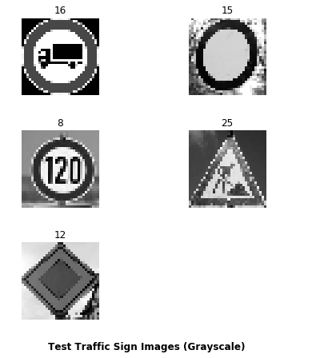

```python
# img = mpimg.imread('test_images/small_120_kmh_limit.png')
# plt.imshow(img)
# #printing out some stats and plotting
# print('This image is:', type(img), 'with dimensions:', img.shape)


flist = os.listdir("test_images/")
# print(flist)

sign_names = pd.read_csv("signnames.csv")
# sign_names.head(5)
img_labes = signname_to_classid(flist,sign_names)
print(img_labes)

images = get_imgs_from_flist(flist)
# print(len(images))
show_images(images,img_labes,"Test Traffic Sign Images (Grayscale)",cols=len(images)//2,
           fig_size=(6,6), show_ticks=False)
```

### Predict the Sign Type for Each Image

```python
### Run the predictions here and use the model to output the prediction for each image.
### Make sure to pre-process the images with the same pre-processing pipeline used earlier.
### Feel free to use as many code cells as needed.
# Lesson 11 deep neural network : Save and Restore TensorFlow Models
import tensorflow as tf
# Remove the previous weights and bias
save_file = './traffic_sign_classifier.chkpt'
# tf.reset_default_graph()
# saver = tf.train.Saver()

prediction = tf.argmax(logits, 1)
with tf.Session(graph=G) as sess:
    saver.restore(sess,save_file)
    logit_prediction = sess.run(prediction,feed_dict={x:images})

    print("The the Sign Type Prediction for Each Image :",logit_prediction)
```

```
INFO:tensorflow:Restoring parameters from ./traffic_sign_classifier.chkpt
The the Sign Type Prediction for Each Image : [16 15  8 25 12]
```

### Analyze Performance

```python
### Calculate the accuracy for these 5 new images.
### For example, if the model predicted 1 out of 5 signs correctly, it's 20% accurate on these new images.

# pred_acc = np.sum(img_labes == logit_prediction) / len(logit_prediction)
# print("[Grayscale Normalised] Predictional accuracy on new images: {0}%".format(pred_acc * 100))


with tf.Session(graph=G) as sess:
    saver.restore(sess,save_file)
    predict_accuracy = evaluate(images,img_labes)
    print("Prediction Accuracy = {:.3f}".format(predict_accuracy))
print("[Grayscale Normalised] Predictional accuracy on new images: {0}%".format(predict_accuracy * 100))
```

```
INFO:tensorflow:Restoring parameters from ./traffic_sign_classifier.chkpt
Prediction Accuracy = 1.000
[Grayscale Normalised] Predictional accuracy on new images: 100.0%
```

### Output Top 5 Softmax Probabilities For Each Image Found on the Web

For each of the new images, print out the model's softmax probabilities to show the **certainty** of the model's predictions (limit the output to the top 5 probabilities for each image). [`tf.nn.top_k`](https://www.tensorflow.org/versions/r0.12/api_docs/python/nn.html#top_k) could prove helpful here.

The example below demonstrates how tf.nn.top_k can be used to find the top k predictions for each image.

`tf.nn.top_k` will return the values and indices (class ids) of the top k predictions. So if k=3, for each sign, it'll return the 3 largest probabilities (out of a possible 43) and the correspoding class ids.

Take this numpy array as an example. The values in the array represent predictions. The array contains softmax probabilities for five candidate images with six possible classes. `tf.nn.top_k` is used to choose the three classes with the highest probability:

```
# (5, 6) array
a = np.array([[ 0.24879643,  0.07032244,  0.12641572,  0.34763842,  0.07893497,
         0.12789202],
       [ 0.28086119,  0.27569815,  0.08594638,  0.0178669 ,  0.18063401,
         0.15899337],
       [ 0.26076848,  0.23664738,  0.08020603,  0.07001922,  0.1134371 ,
         0.23892179],
       [ 0.11943333,  0.29198961,  0.02605103,  0.26234032,  0.1351348 ,
         0.16505091],
       [ 0.09561176,  0.34396535,  0.0643941 ,  0.16240774,  0.24206137,
         0.09155967]])
```

Running it through `sess.run(tf.nn.top_k(tf.constant(a), k=3))` produces:

```
TopKV2(values=array([[ 0.34763842,  0.24879643,  0.12789202],
       [ 0.28086119,  0.27569815,  0.18063401],
       [ 0.26076848,  0.23892179,  0.23664738],
       [ 0.29198961,  0.26234032,  0.16505091],
       [ 0.34396535,  0.24206137,  0.16240774]]), indices=array([[3, 0, 5],
       [0, 1, 4],
       [0, 5, 1],
       [1, 3, 5],
       [1, 4, 3]], dtype=int32))
```

Looking just at the first row we get `[ 0.34763842, 0.24879643, 0.12789202]`, you can confirm these are the 3 largest probabilities in `a`. You'll also notice `[3, 0, 5]` are the corresponding indices.

```python
### Print out the top five softmax probabilities for the predictions on the German traffic sign images found on the web.
### Feel free to use as many code cells as needed.
def softmax(x):
    """Compute softmax values for each sets of scores in x."""
    return np.exp(x) / np.sum(np.exp(x), axis=0)
```

```python
# topk = tf.nn.top_k(tf.nn.softmax(logits),k=5)
# with tf.Session(graph=G) as sess:
#     saver.restore(sess,save_file)
#     topk_softmax = sess.run(topk,feed_dict={x:images})
#     print("The top five softmax probabilities for the predictions on the German traffic sign images :",topk_softmax)
```

```python
preds = tf.argmax(logits, 1)
topk = tf.nn.top_k(tf.nn.softmax(logits),k=5)
with tf.Session(graph=G) as sess:
    saver.restore(sess,save_file)
    topk_softmax,predictions = sess.run((topk,preds),feed_dict={x:images})
    print(predictions)
    print("The top five softmax probabilities for the predictions on the German traffic sign images :",topk_softmax)
```

```
INFO:tensorflow:Restoring parameters from ./traffic_sign_classifier.chkpt
[16 15  8 25 12]
The top five softmax probabilities for the predictions on the German traffic sign images : TopKV2(values=array([[  9.58546102e-01,   3.42689492e-02,   2.53663352e-03,
          1.88723521e-03,   5.20639005e-04],
       [  9.94294107e-01,   5.38867572e-03,   3.04565736e-04,
          5.65480923e-06,   2.69407042e-06],
       [  1.00000000e+00,   8.68184913e-10,   3.35797057e-10,
          2.67344532e-11,   2.01964639e-12],
       [  9.97742772e-01,   1.93161878e-03,   2.73924699e-04,
          4.36694900e-05,   4.93047037e-06],
       [  1.00000000e+00,   2.82069879e-09,   7.42742423e-10,
          5.69697622e-10,   3.38144096e-11]], dtype=float32), indices=array([[16, 40, 19, 37,  9],
       [15, 13, 12,  9, 22],
       [ 8,  7,  4,  0, 39],
       [25, 22, 20, 24, 30],
       [12, 40,  9, 41, 32]], dtype=int32))
```

### Project Writeup

Once you have completed the code implementation, document your results in a project writeup using this [template](https://github.com/udacity/CarND-Traffic-Sign-Classifier-Project/blob/master/writeup_template.md) as a guide. The writeup can be in a markdown or pdf file.

## Step 4 (Optional): Visualize the Neural Network's State with Test Images

This Section is not required to complete but acts as an additional excersise for understaning the output of a neural network's weights. While neural networks can be a great learning device they are often referred to as a black box. We can understand what the weights of a neural network look like better by plotting their feature maps. After successfully training your neural network you can see what it's feature maps look like by plotting the output of the network's weight layers in response to a test stimuli image. From these plotted feature maps, it's possible to see what characteristics of an image the network finds interesting. For a sign, maybe the inner network feature maps react with high activation to the sign's boundary outline or to the contrast in the sign's painted symbol.

Provided for you below is the function code that allows you to get the visualization output of any tensorflow weight layer you want. The inputs to the function should be a stimuli image, one used during training or a new one you provided, and then the tensorflow variable name that represents the layer's state during the training process, for instance if you wanted to see what the LeNet lab's feature maps looked like for it's second convolutional layer you could enter conv2 as the tf_activation variable.

For an example of what feature map outputs look like, check out NVIDIA's results in their paper [End-to-End Deep Learning for Self-Driving Cars](https://devblogs.nvidia.com/parallelforall/deep-learning-self-driving-cars/) in the section Visualization of internal CNN State. NVIDIA was able to show that their network's inner weights had high activations to road boundary lines by comparing feature maps from an image with a clear path to one without. Try experimenting with a similar test to show that your trained network's weights are looking for interesting features, whether it's looking at differences in feature maps from images with or without a sign, or even what feature maps look like in a trained network vs a completely untrained one on the same sign image.

[figure not shown]

Your output should look something like this (above)

```python
### Visualize your network's feature maps here.
### Feel free to use as many code cells as needed.

# image_input: the test image being fed into the network to produce the feature maps
# tf_activation: should be a tf variable name used during your training procedure that represents the calculated state of a specific weight layer
# activation_min/max: can be used to view the activation contrast in more detail, by default matplot sets min and max to the actual min and max values of the output
# plt_num: used to plot out multiple different weight feature map sets on the same block, just extend the plt number for each new feature map entry

def outputFeatureMap(image_input, tf_activation, activation_min=-1, activation_max=-1 ,plt_num=1):
    # Here make sure to preprocess your image_input in a way your network expects
    # with size, normalization, ect if needed
    # image_input =
    # Note: x should be the same name as your network's tensorflow data placeholder variable
    # If you get an error tf_activation is not defined it may be having trouble accessing the variable from inside a function
    activation = tf_activation.eval(session=sess,feed_dict={x : image_input})
    featuremaps = activation.shape[3]
    plt.figure(plt_num, figsize=(15,15))
    for featuremap in range(featuremaps):
        plt.subplot(6,8, featuremap+1) # sets the number of feature maps to show on each row and column
        plt.title('FeatureMap ' + str(featuremap)) # displays the feature map number
        if activation_min != -1 & activation_max != -1:
            plt.imshow(activation[0,:,:, featuremap], interpolation="nearest", vmin =activation_min, vmax=activation_max, cmap="gray")
        elif activation_max != -1:
            plt.imshow(activation[0,:,:, featuremap], interpolation="nearest", vmax=activation_max, cmap="gray")
        elif activation_min !=-1:
            plt.imshow(activation[0,:,:, featuremap], interpolation="nearest", vmin=activation_min, cmap="gray")
        else:
            plt.imshow(activation[0,:,:, featuremap], interpolation="nearest", cmap="gray")
```